# 3 Navigating the command line

## 3.7 `wget`: Download data

Next, let’s download a fasta file that contains the sequence of a 16S rRNA gene. This file will be useful to learn about some other commands. Below, we use the `wget` command to fetch a fasta file from an online website as follows:

```bash
# Download the example fasta file into the current directory
wget https://github.com/ndombrowski/MicEco2025/raw/refs/heads/main/data/LjRoot303.fasta.gz
```

**ImportantWget for Mac users**

For Mac users wget is not installed by default. If you do not want to install it, you can instead use the `curl` command:

```bash
# -O: save the file under its oroginal name
# -L: Tells curl that if the server tells it to go somewhere else, follow it until you reach the actual file
curl -LO https://github.com/ndombrowski/MicEco2025/raw/refs/heads/main/data/LjRoot303.fasta.gz
```

After you download any kind of data, it is always a good idea to do some sanity check to see if the file is present and know how large it is (or whether it is empty and something went wrong during the download):

```bash
# List files in long (-l) and human-readable (-h) format
# combining these two commands becomes -lh
# You should see that the file exists and is not empty
ls -lh LjRoot303.fasta.gz
```

## 3.8 `cp`: Copy files

`cp` duplicates files or directories. It is a useful feature to keep our files organized and not have every single file in a single folder but instead to organize your files into folder categories (useful folders can be: data, scripts and results).

Let’s use `cp` to copy the downloaded file into `data` and to organize the data a bit better:

```bash
# Copy the file into data
cp LjRoot303.fasta.gz data/

# Show the content of both locations
ls -l
ls -l data
```

When running the two `ls` commands, we see that we now have two copies of `LjRoot303.fasta.gz`, one file is in our working directory and the other one is in our data folder. Having large files in multiple locations is not ideal since we will use unnecessary space. However, we can use another command to move the file into our data folder instead of copying it.

## 3.9 `mv`: Move (or rename) files

`mv` moves or renames files without creating a second copy:

```bash
# Move the file into data
mv LjRoot303.fasta.gz data/

# Verify
ls -l
ls -l data
```

Notice that `mv` will move a file and, without asking, overwrite the existing file we had in the data folder when we ran `cp`. This means that if you run `mv` its best to make sure that you do not overwrite files by mistake.

## 3.10 `rm`: Remove files and directories

To remove files and folders, we use the `rm` command. For example we could remove the `LjRoot303.fasta.gz` in case we don’t need it anymore:

```bash
# Remove the fasta file from the data folder
rm data/LjRoot303.fasta.gz

# Check if that worked
ls -l data
```

If we want to remove a folder, we need to tell `rm` that we want to remove folders using an option. To do this, we use `-r` , which allows us to remove directories and their contents recursively.

**Important**

**Unix does not have an undelete command.**

This means that if you delete something with `rm`, it’s gone. Therefore, use `rm` with care and check what you write twice before pressing enter!

Also, NEVER run `rm -r` or `rm -rf` on the root `/` folder or any important path. And yes, we have these combinations online. Therefore, always double check the path or file name before pressing enter when using the `rm` command.

**QuestionTask**

Download another fasta file:

**AnswerClick to see the answer**

```bash
# Download the file
wget https://github.com/ndombrowski/MicEco2025/raw/refs/heads/main/data/GCF_000714595.fasta.gz

# Move the file to the data folder
mv GCF_000714595.fasta.gz data

# Check the file size
ls -lh data/
```

## 3.11 `gzip`: (Un)compressing files

You might have noticed that the file we downloaded ends with `.gz`. This extension is used for files that are compressed to make the file smaller. This is useful for saving files and saving space, but this makes the file unreadable for a human. To be able to learn how to read the content of a file, let’s learn how to uncompress the file first.

```bash
# Download another file
# Here, we use the -P option to directly download the file into the data folder
wget -P data https://github.com/ndombrowski/MicEco2025/raw/refs/heads/main/data/LjRoot303.fasta.gz

# Check that this worked
# You now should see two files
ls -l data

# Uncompress the file with gzip
# Here, we use -d to decompress the file
# (by default gzip will compress a file)
gzip -d data/LjRoot303.fasta.gz

# Check that this worked
# We now should see that one file is uncompressed (i.e. it lost the gz extension)
ls data
```

**ImportantWget -P for Mac users**

For Mac users that use `curl` instead of `wget`, you can redirect the file to a specific folder like this:

```bash
curl --output-dir data -LO https://github.com/ndombrowski/MicEco2025/raw/refs/heads/main/data/LjRoot303.fasta.gz
```

## 3.12 Exploring file contents

Now that we have the uncompressed file we can use different ways to explore the content of a file.

### 3.12.1 `cat`: Print the full file

We can use `cat` print the entire file to the screen, this is useful for smaller files, but can get overwhelming for long ones where you would see hundreds of line just flying over the screen.

```bash
cat data/LjRoot303.fasta
```

### 3.12.2 `head` and `tail`: View parts of a file

To only print the first few or last few lines we can use the `head` and `tail` commands:

```bash
# Show the first 10 lines
head data/LjRoot303.fasta

# Show the last 5 lines
# Here, the option -n allows us to control how many lines get printed
tail -n 5 data/LjRoot303.fasta
```

### 3.12.3 `less`: View the full file

`less` let’s you view a file’s contents one screen at a time. This is useful when dealing with a large text file (such as a sequence data file) because it doesn’t load the entire file but accesses it page by page, resulting in fast loading speeds.

```bash
less -S data/LjRoot303.fasta
```

- You can use the arrow Up and Page arrow keys to move through the text file
- To exit less, type `q`

### 3.12.4 `zcat`: Decompress and print to screen

When we used gzip above, we decompressed the file and that allowed us to read the content of the fasta file. This is perfect for smaller files, but not ideal for sequence data since these files get large and we might not want to decompress these files as they would clutter our system.

Luckily, there is one useful tool in bash to decompress the file and print the content to the screen. `zcat` will print the content of a file to the screen but leave the file as is.

```bash
# Check the content of the data folder
# We should have one compressed and one uncompressed file
ls -l data

# Use zcat on the compressed file to view its content
zcat data/GCF_000714595.fasta.gz

# Check the content of the data folder
# We still should have one compressed and one uncompressed file
ls -l data
```

**ImportantZcat for Mac users**

For Mac users using the zsh shell, zcat might not work as expected. Try using gzcat instead:

```bash
gzcat data/GCF_000714595.fasta.gz
```

**TipTip: Editing text files with `nano`**

You can also edit the content of a text file and there are different programs available to do this on the command line, one such tool is `nano`, which should come with most command line interpreters. You can open any file as follows:

```bash
nano data/LjRoot303.fasta
```

Once the document is open you can edit it however you want and then

- Close the document with `Control + X`
- Type `y` to save changes and press enter

## 3.13 `wc`: Count things

Another useful tool is the `wc` (short for *wordcount*) command that allows us to count the number of lines via `-l` in a file. It is an useful tool for sanity checking.

```bash
wc -l data/LjRoot303.fasta
```

We see that this file contains 20 lines of text. For fasta files this is not very informative, but if you for example work with a dataframe with rows and columns where you filter rows using certain conditions this can become very useful for sanity checking.

## 3.14 `grep` : print lines that match patterns

The `grep` command searches for patterns in a file. We could for example use this to ask how many 16S rRNA gene sequences are in our fasta file by searching for the fasta header that always starts with a `>`. The basic grep syntax is `grep "pattern" file`. Here, “pattern” is the text you want to search for, and file is the file you want to search in. The double quotes allow us to include special characters (like `>`) safely.

```bash
grep ">" data/LjRoot303.fasta
```

This prints all lines that match the pattern (here: `>`). In a fasta file, `>` is used to label the sequence headers. Depending on your terminal, the matches might be highlighted, which makes them easy to spot.

If we only want to count the number of headers, we can use the `-c` option:

```bash
# Root303 contains 1 16S rRNA gene sequence
grep -c ">" data/LjRoot303.fasta
```

**TipTip: The structure of sequence files**

A sequence FASTA file is a text based format to store DNA or peptide sequences. It should always look something like this:

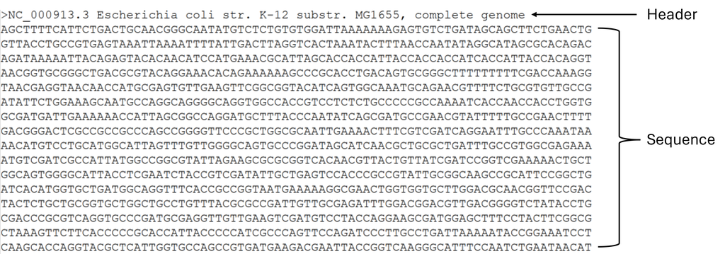

The header always starts with a `>` followed by descriptive information. In a new line the sequence data gets stored in either a single line or multiple lines. A fasta file can contain a single sequence or multiple sequences.

By convention the extension `.fna` is used to store fasta sequences from nucleotides and `.faa` is used to store fasta sequences from proteins. The extension `.fasta` can contain either nucleotide or protein sequences.

Another common extension is `fastq`. Fastq files are used to store sequencing data generated by sequencers and contain four lines of information: (i) the sequence header, (ii) the sequence itself, (iii) a separator and (iv) information about the quality of each single base pair in the sequence. They typically look something like this:

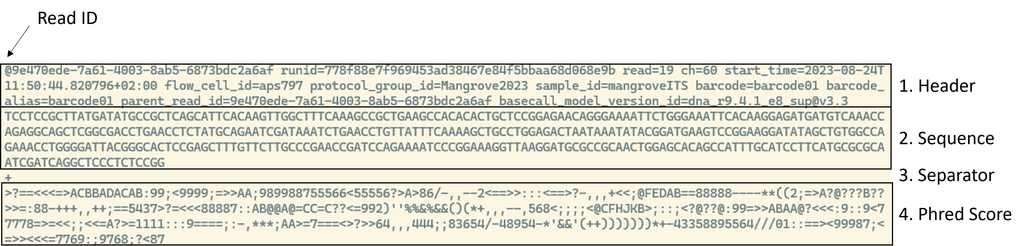

**QuestionTask**

1. Uncompress the file for GCF_000714595
2. Compare the number of 16S rRNA gene sequences for GCF_000714595 and LjRoot303
3. What could it mean if one microbial species has more 16S rRNA gene sequences than another?

**AnswerClick to see the answer**

```bash
# Uncompress
gzip -d data/GCF_000714595.fasta.gz

# Count the number of contigs
# LjRoot303 has 1 and and GCF_000714595 9 16S rRNA gene sequences
grep -c ">" data/LjRoot303.fasta
grep -c ">" data/GCF_000714595.fasta
```

Answer for question 3:

Bacteria can carry multiple copies of the rRNA operon (16S–23S–5S). A higher copy number is often associated with fast-responding, fast-growing life strategies (more ribosomes → faster protein synthesis under nutrient-rich conditions).

This can cause problems in, for example, 16S rRNA gene amplicon analyses:

- A single organism may produce multiple slightly distinct 16S sequences, inflating apparent diversity
- Species with higher 16S copy number will produce more amplicon reads per cell. So raw read counts overestimate their true cell abundance unless you correct for copy number (which is difficult)